# Tutorium 9

Gruppen 2 und 4  
Samuel Teuber  
propa@teuber.dev  
https://teuber.dev/propa

# Übungsblätter

- Fragen?
- Probleme?
- Zu schwierig?

# Übungsblatt 8

## Aufgabe 1: Grundlagen der Parallelisierung

> Es sollen **Kanten in einem Bild** (angegeben durch eine Matrix bestehend aus Pixeln) detektiertwerden. Hierfür können **Faltungsmatrizen zur Kantendetektion angewandt werden**, welche **für jeden Pixel des Bildes** einen Farbgradienten berechnen. Eine Faltungsmatrix beschreibt hierbeifür einen Pixel, welche der umliegenden Pixel für die Berechnung des Gradienten verwendet werden und den gewichteten Einfluss jedes umliegenden Pixels auf den Gradienten.

**Parallelisierungsmethodologie?**

**Datenparallelismus!**

## Aufgabe 1: Grundlagen der Parallelisierung

> Es soll ein **Integral numerisch** berechnet werden.

**Parallelisierungsmethodologie?**

**Datenparallelismus!**

## Aufgabe 1: Grundlagen der Parallelisierung

> Es soll einen Webserver programmiert werden, der **mehrere Anfragen bearbeiten** kann.

**Parallelisierungsmethodologie?**

**Taskparallelismus!**

## Aufgabe 2: Zeiger-Arithmetik

```
#include<stdio.h>
int global[] = {1, 2, 3, 4, 5};
int *magic(int x[],int y) {
    printf("m");
    global[1] = *(global + y) + 3;
    return&x[y - 2];
}

int main() {
    printf("%i", *magic(&global[1], *(global + 1)));
    return 0;
}
```

**Ausgabe?**

```
m6
```

## Aufgabe 3: MPI Send/Receive

```
int main(int argc, char*argv[]) {
    MPI_Init(&argc, &argv);
    int my_rank;
    MPI_Comm_rank(MPI_COMM_WORLD, &my_rank);
    if (my_rank < 2) {
        int other_rank = 1 - my_rank;
        int tag        = 0;
        char message[14];
        sprintf(message, "Hello, I am %d", my_rank);
        MPI_Status status;

        MPI_Send(message, strlen(message) + 1, MPI_CHAR, other_rank, tag,MPI_COMM_WORLD);
        MPI_Recv(message, 100, MPI_CHAR, other_rank, tag, MPI_COMM_WORLD, &status);
        printf("%s\n", message);
    }
    MPI_Finalize();
    return EXIT_SUCCESS;
}
```

- Funktionierte beim Test
- Funktioniert nicht bei Kunden **Problem??**

**Kommunikationsmodus** (Buffered vs. Synchronized/Ready)

### Lösungsstrategien?

- Unterschiedliches Verhalten je nach Prozess
- Erzwinge gepufferten Modus: `MPI_Bsend`  
  Wichtig: Genügend Systempuffer vorhanden, Nutzung erzwingen mit `MPI_Buffer_attach`
- Nicht blockierende Kommunikation nutzen (`MPI_Isend`)  
  Wichtig: Weiterer Puffer für Receive notwendig
- Kombinierte Sende- und Empfangsoperation: `MPI_Sendrecv` oder `MPI_Sendrecv_replace`

## Aufgabe 4: Send/Receive zu kollektiven Operationen

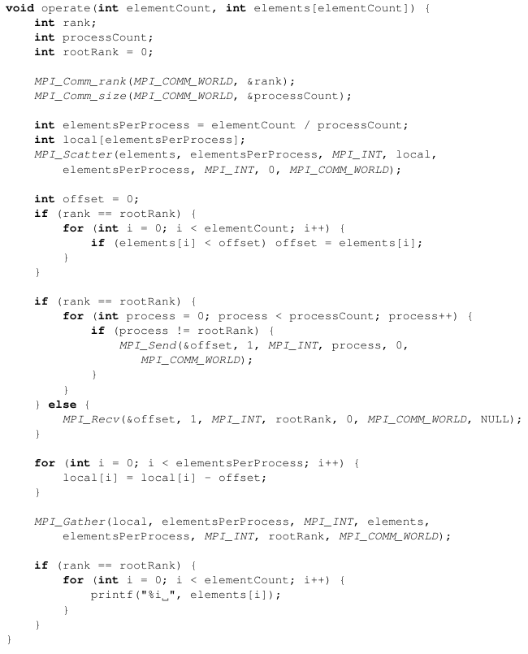

**Funktion:** Erhöht alle Werte von `elements` um Differenz zwischen null und kleinstem Wert in Array, falls kleinster Wert kleiner null

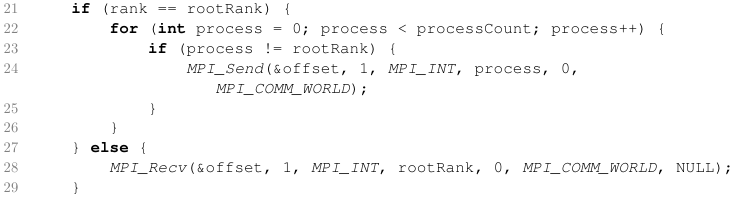

```
MPI_Bcast(&offset, 1, MPI_INT, rootRank, MPI_COMM_WORLD);
```

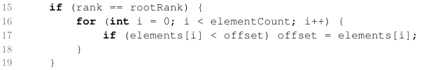

```
int localOffet = 0;
for (int i = 0; i < elementsPerProcess; i++) {
    if (local[i] < localOffset) localOffset = local[i];
}
MPI_Reduce(&localOffset, &offset, 1, MPI_INT, MPI_MIN, rootRank, MPI_COMM_WORLD);
```

## Aufgabe 5: MPI Reduce

```
|void my_int_sum_reduce(int *sendbuf, int *recvbuf, int count, int root, MPI_Comm comm) {
|    int size, rank;
|    MPI_Comm_size(comm,&size);
|    MPI_Comm_rank(comm,&rank);
```

```
|    if (rank == root) {
```

```
|        for (int i = 0; i<count; i++) {
|            recvbuf[i] = sendbuf[i]
|        }
```

```
|        for (int i = 0; i < size; i++) {
|            if (i == root) continue;
|
|            int other[count];
|            MPI_Recv(other, count, MPI_INT, i, 0, comm, MPI_STATUS_IGNORE);
|            for (int j = 0; j < count; j++)
|                recvbuf[j] += other[j];
|        }
```

```
|    } else {
|        MPI_Send(sendbuf, count, MPI_INT, root, 0, comm);
|    }
|}
```

## Aufgabe 6: MPI Matrix Multiplikation

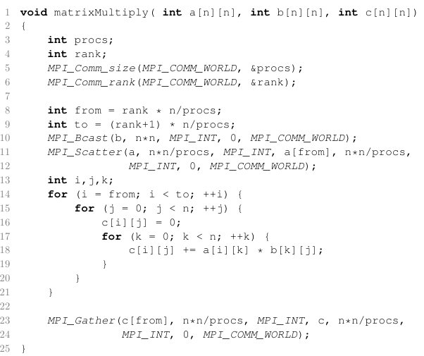

# Java und Multithreading

## Java: Kennen wir schon

```
class Main {
    public static void main(String[] args) {
        System.out.println("Hello World!");
    }
}
```

## Lambdas in Java

Neues Feature seit Java 8

#### Statt...

```
public void add(int i, int j) {
    return i + j;
}
```

#### schreiben wir...

```
(int i, j) -> i + j
```

## Grundlage: Functional Interfaces und Method References

**Functional Interfaces:** Interface mit einzelner Funktion

```
@FunctionalInterface
interface Predicate {
    boolean check(Integer value);
}
//...
public int sum(List<Integer> values, Predicate predicate) {
    //...
}
```

**Method References:** Methodenreferenz als Argument für Funktionsinterface

```
public class SimpleCheckers {
    public static boolean checkSomething(Integer value) { /*...*/ }
}
sum(values, SimpleCheckers::checkSomething)
```

```
sum(values, (Integer v) -> v>0);
```

## Threads in Java

- Innerhalb von **einem** Prozess
- Geteilter Heap
- Jeder Thread hat eigenen Stack
- Code-Ausführung zunächst unabhängig

**Beispiel:** `Java1`

## Thread Scheduling in Java

- Scheduling kennen wir schon aus anderen Vorlesungen (z.B. OS)
- Wird auch hier verwendet: Verteilung von Threads auf verfügbare Kerne
- Priorität kann mit `(new Thread())->setPriority(int priority)` beeinflusst werden

## Race Conditions: Counters

- Wenn die Reihenfolge, in welcher Threads ihre Instruktionen ausführen, das Ergebnis beeinflussen
- Notwendige Bedingung bei geteiltem Speicher: Lese- *und* Schreibzugriff

**Beispiel:** `Java2`

## Atomic Statements in Java

> Executed complete or not at all
- Lesen/Schreiben von Variablen
- Lesen/Schreiben primitiver Variablen
  - Immer für 32 Bit Werte
  - Je nach System evtl. nicht für 64 Bit Werte (z.B. `long` oder `double`)
- Lesen/Schreiben auf allen `volatile` Variablen

**NICHT:** `a++`

### Möglicher Lösungsansatz: Mutual Exclusion

*Critical Section* darf nur von einzigem Thread betreten werden

Performance **vs** Korrektheit: **Amdahl's Law**

#### Java: Monitore

```
public void doSomething() {
    synchronized(someObject) {
        // critical section for someObject
    }
}
```

```
public synchronized void doSomething() {
    // critical section for doSomething
}
```

## Übungsaufgabe

- Wie beheben wir die Race Condition im Counter Beispiel?

`Java2`

- Wie fügen wir eine `decrement` Methode (ohne Race Condition) hinzu?

## Deadlocks: Coffman Bedingungen

- Mutual Exclusion
- Hold and Wait
- No preemption
- Circular wait

**Philosophenproblem:**

- 5 Philosophen sitzen an Tisch, 5 Teller Spaghetti, 5 Gabeln
- Jeder Philosoph braucht 2 Gabeln um zu essen (jeweils links und rechts von ihm)
- Wenn verfügbar: Philosoph nimmt sich Gabel rechts
- Wenn verfügbar: Philosoph nimmt sich Gabel links
- Wenn nicht verfügbar: Wartet (und behält Besteck in der Hand)

`Java4`

## Livelock

- Kein Deadlock
- Threads arbeiten, **aber...**
- ...kommen **nicht voran**

## Guarded Block

```
while(!condition) {}
```

**busy waiting!**

**Besser:**

- `while(!condition) {wait();}`
- `notify()`
- `notifyAll()`

**Warum trotzdem `while`?**

## Übungsaufgabe: Consumer/Producer

`Java3`

```
class Producer extends Thread {
    private Queue queue;
    public Producer(Queue queueParam) {
        this.queue = queueParam;
    }
    public void run() {
        while(true) {
            queue.produce(new Task(ThreadLocalRandom.current().nextInt(0, 100), ThreadLocalRandom.current().nextInt(0, 100)));
        }
    }
}
class Consumer extends Thread {
    private Queue queue;
    public Consumer(Queue queueParam) {
        this.queue = queueParam;
    }
    public void run() {
        while (true) {
            Task t = this.queue.consume();
            System.out.println(t.add());
        }
    }
}
```

## Weitere Konzepte

- Immutable Objects (private und final)
- Defensive Copies (bei In- und Output)

**Zu Hause anschauen...**

## Happens-Before: Memory Consistency

```
public class Main {
    static int flag = 0;
    public static void main(String[] args) {
        Thread t1 = new Thread(() -> flag = 1);
        Thread t2 = new Thread(() -> {
            System.out.print(flag);
            System.out.print(flag);
        });
        t1.start();
        t2.start();
    }
}
```

**Ausgabe `00` - Warum?**

- `t2` wird vor `t1` ausgeführt
- `t1` wird **vor** zweitem sysout in `t2` ausgeführt werden, **aber** `flag` in Cache von `t2`

**Lösung:** `volatile flag`

## Happens-Before: Reordering

```
public class Main {
    public static void main(String[] args) {
        State state = new State();
        (new Thread( () -> {
            state.a = 1;
            state.b = 1;
            state.c = state.a + 1;
        })).start();
        (new Thread( () -> {
            if(state.c == 2 && state.b == 0) {
                System.out.println("Wrong");
            }
        })).start();
    }
}

public class State {
    int a = 0;
    int b = 0;
    int c = 0;
}
```

**Ausgabe:** `Wrong`

Instruction reordering - tatsächlich ausgeführt in Thread 1:

```
state.a = 1;
state.c = state.a + 1;
state.b = 1;
```

**Lösung:** `volatile int c = 0;`

# Java Advanced

## Atomic Types

`java.util.concurrent.atomic`

Bsp: `AtomicInteger`

- `int get()`
- `int incrementAndGet()`
- `int decrementAndGet()`
- `bool compareAndSet(int oldValue, int newValue)`

**Zurück zum Counter Beispiel**

## Locks und Semaphoren

- `ReentrantLock`

  ```
  Lock lock= new ReentrantLock(false);
  // ...
  lock.lock();
  c++;
  lock.unlock();
  ```

- `Semaphore`

  ```
  Semaphore sem = Semaphore(int capacity, boolean fair);
  // ...
  sem.acquire();
  c++
  sem.release();
  ```

- Barrieren
  - `CyclicBarrier(int n)` (reentrant)
  - `CountDownLatch(int n)` (nicht reentrant)

## Executor & ExecutorService

```
ExecutorService executor = Executors.newSingleThreadExecutor();

executor.execute(() -> {
    String threadName = Thread.currentThread().getName();
    System.out.println("Hello " + threadName);
});
try{
    executor.shutdown();
    executor.awaitTermination(5, TimeUnit.SECONDS);
} catch(InterruptedExceptionex) {
} finally { if(!executor.isTerminated()) { executor.shutdownNow(); }}
```

**Auch:** `newFixedThreadPool(int c)`

# Futures

```
ExecutorService executorService = Executors.newCachedThreadPool();
List<Future<Integer>> list;
// ....
for (int i= 0; i< 10; i++) {
    final int currentValue= i;
    Callable<Integer> myCallable= () -> { return fib(currentValue); };
    list.add(executorService.submit(myCallable));
    // Abrufbar mit
    Integer result = future.get();
}
// ...
for(Future<Integer> curFuture : list) {
    Integer result = curFuture;
    // ...
}
executorService.shutdownNow();
```

## Zusätzlich

- CompletableFutures (Callback)
- Fork-Join
- Streams